# PhillyR: Packages & HTMLWidgets

Scott Jackson

1/25/2018

## Set Up This Presentation

```bash
git clone https://github.com/scottmmjackson/webvrr
pushd webvrr
git checkout 22bed0102f2b23065d0a6896efd5dcd6af4f25ed
popd
```

```
## Cloning into 'webvrr'...
## ~/meetup/phillyr-1-25-18/webvrr ~/meetup/phillyr-1-25-18
## Note: checking out '22bed0102f2b23065d0a6896efd5dcd6af4f25ed'.
##
## You are in 'detached HEAD' state. You can look around, make experimental
## changes and commit them, and you can discard any commits you make in this
## state without impacting any branches by performing another checkout.
##
## If you want to create a new branch to retain commits you create, you may
## do so (now or later) by using -b with the checkout command again. Example:
##
##   git checkout -b <new-branch-name>
##
## HEAD is now at 22bed01... 0.0.2 major update
## ~/meetup/phillyr-1-25-18
```

*Always Make Your Research Reproducible* – Ancient R Proverb

## HTMLWidgets Package Layout

```bash
tree -L 2 webvrr
```

```
## webvrr
## ├── DESCRIPTION
## ├── NAMESPACE
## ├── R
## │   └── webvrr.R
## ├── README.md
## ├── gulpfile.js
## ├── inst
## │   └── htmlwidgets
## ├── javascript
## │   └── src
## ├── man
## │   ├── addBackground.Rd
## │   ├── addInnerTexturedSphere.Rd
## │   ├── addToScene.Rd
## │   └── webvrr.Rd
## ├── package.json
## └── webvrr.Rproj
##
## 6 directories, 11 files
```

## Making A New HTMLWidgets Project in RStudio

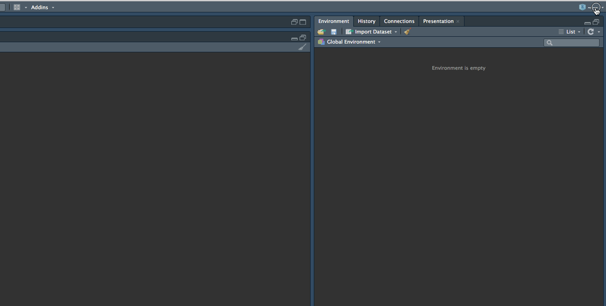

## What Now?

```bash
tree myAwesomePackage
```

```
## myAwesomePackage
## ├── DESCRIPTION
## ├── NAMESPACE
## ├── R
## │   └── hello.R
## ├── man
## │   └── hello.Rd
## └── myAwesomePackage.Rproj
##
## 2 directories, 5 files
```

## What’s Missing?

- `inst` - “installed files” (community convention)
- `javascript` - Excluded from the build process, for developer convenience
- `package.json`, `gulpfile.js` - For your Javascript build pipeline, if you want it

## The `inst/htmlwidgets` directory

```bash
mkdir -p myAwesomePackage/inst/htmlwidgets
tree myAwesomePackage/inst
```

```
## myAwesomePackage/inst
## └── htmlwidgets
##
## 1 directory, 0 files
```

```bash
tree -L 1 webvrr/inst/htmlwidgets
```

```
## webvrr/inst/htmlwidgets
## ├── lib
## ├── webvrr.js
## └── webvrr.yaml
##
## 1 directory, 2 files
```

## More on `inst/htmlwidgets` directory

- `<widgetname>.js`
  - javascript assets for your htmlwidget
  - filename (widgetname) should be the same as the name provided in the `htmlwidgets::createWidget` call
- `<widgetname>.yaml`
  - declares the dependencies for your javascript assets

## `<widgetname>.yaml`

```bash
cat webvrr/inst/htmlwidgets/webvrr.yaml
```

```
## dependencies:
##   - name: threejs
##     src: "htmlwidgets/lib/three.js"
##     version: "0.89.0"
##     script:
##      - "build/three.min.js"
##      - "examples/js/controls/VRControls.js"
##      - "examples/js/effects/VREffect.js"
##   - name: "webvr-ui"
##     src: "htmlwidgets/lib/webvr-ui"
##     version: "0.9.4"
##     script: "build/webvr-ui.min.js"
##   - name: "webvr-polyfill"
##     src: "htmlwidgets/lib/webvr-polyfill"
##     script: "build/webvr-polyfill.js"
##     version: "0.10.2"
##   - name: "styles"
##     src: "htmlwidgets/lib/styles"
##     stylesheet: "webvrr.css"
##     version: "0.0.1"
```

## How do you install javascript dependencies?

- Bower is appropriate here.
- `npm install -g bower`

```bash
cat webvrr/.bowerrc
```

```
## {"directory": "inst/htmlwidgets/lib"}
```

## How does this get used in R?

```bash
head -n 25 webvrr/R/webvrr.R  | tail -n 13
```

```
## webvrr <- function(
##   width = NULL,
##   height = NULL
## ) {
##   htmlwidgets::createWidget(
##     name = "webvrr",
##     x = list(
##       calls = list()
##     ),
##     width = width,
##     height = height
##   )
## }
```

## Composing Functions

```bash
head -n 104 webvrr/R/webvrr.R  | tail -n 10
```

```
## addToScene <- function(
##   vr,
##   call = list()
## ) {
##   vr$x$calls <- lapply(1:(length(vr$x$calls)+1), function(y) {
##     if(y > length(vr$x$calls)) call
##     else vr$x$calls[[y]]
##   })
##   vr
## }
```

- The `x` here is the same `x` argument to `createWidget`

## Composing Continued

```bash
tail -n 20 webvrr/R/webvrr.R
```

```
## addInnerTexturedSphere <- function(
##   vr,
##   texture = NULL,
##   `repeat`= list(
##     repeatX = 32,
##     repeatY = 32
##   ),
##   radius = 5,
##   widthSegments = 32,
##   heightSegments = 32
## ) {
##   if(`repeat` != FALSE) stopifnot(is.list(`repeat`))
##   addToScene(vr, list(
##     type = "innerTexturedSphere",
##     `repeat` = `repeat`,
##     radius = radius,
##     widthSegments = widthSegments,
##     heightSegments = heightSegments
##   ))
## }
```

## How about on the Javascript Side?

- I will show you how my actual Javascript looks later on.
- It’s written in ES6 + Flow, which is why I have a full JS compilation pipeline in the package.
- For now, you’ll get to see a much simpler example

## Ok, what’s this fake example look like?

```javascript
// webvrr.js - not really though
HTMLWidgets.widget({
  name: 'webvrr',
  type: 'output',
  factory: function(el, width, height) {
    return {
      resize: function(newWidth, newHeight) {
        // do something here
        // no return value
      },
      renderValue: function(x) {
        // this is the same x we saw in createWidget
        // use `jsonlite::toJson` to see what it looks like
      },
      // more functions?
    }
  }
});
```

## Dependencies?

- Recall: `<widgetname>.yaml`
- Dependencies are concatenated! (eww, globals)
- If you’re like me and you use ES6+ modules, use this pattern (`leaflet` htmlwidgets use it too!)

```javascript
///// webvrr.js - the real one
///// SNIP
import THREE from './global/three';
///// SNIP

///// ./global/three.js
// @flow
export default global.THREE;

///// That's it. That's the whole file.
```

## Composing Functions: JS Part

```javascript
function doCall(c, scene) {
  switch (c.type) {
  // ... do some stuff to Scene
  }
}
// ...
// renderValue(x) {
// var calls = x.calls;
        (calls || []).forEach(c => doCall(c, scene));
// }
```

## Alright, I have a package, what now?

- Document all the things! http://r-pkgs.had.co.nz/man.html
- Write R tests: http://r-pkgs.had.co.nz/tests.html
- Write Javascript tests: https://mochajs.org/
- Make a README.md and check it in to github
  - Others can `devtools::install_github()` your package now!
- Build, check, and test your project
  - Run `roxygen::roxygenize(".")` frequently

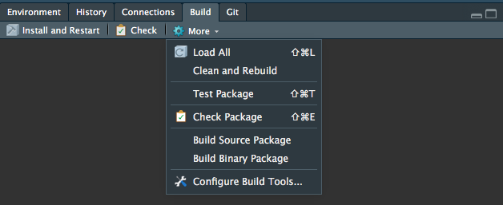

## Check Results

The goal:

```
R CMD check results
0 errors | 0 warnings | 0 notes
```

… but we’re likely to get a warning that our package is huge and it’s all in our `inst/htmlwidgets` directory

## Oh no, my package is huge now

[figure not shown]

- Javascript dependencies are really bad about this.

```r
devtools::use_build_ignore(
  list.files(
    "inst/htmlwidgets/lib/",
    recursive = TRUE, include.dirs = FALSE
  )
)
```

## Clean up

- Remove the files from `.RBuildIgnore` that you want to keep
- Hint: They’re in your `<widgetname>.yaml` config